# Sesion 3 | Part 2 : Gene expression analysis

### 6.2. Clustering analysis

Another common data exploration technique used is clustering analysis. A distance is calculated between samples based on some combination of variable and a distance matrix generated. A clustering algorithm is then run over the distance matrix that aggregates/groups samples based on their distance. There are several clustering methods and several clustering packages available in R. Of particular use in this context are the heirarchical clustering functions hclust() available as a base R function and pvclust() available in the pvclust package (Suzuki and Shimodaira, 2006). The advantage with the pvclust() function is it uses bootstrapping to provide a level of confidence that the observed clusters are robust to slight changes in the samples.

#### 6.2.1. Clustering with hclust() function

More details here: https://2-bitbio.com/2017/04/clustering-rnaseq-data-making-heatmaps.html

First, data as cpm:

```r
cpmCounts <- cpm(dgList3, log=TRUE, prior.count=1)
cpmCounts <- cpmCounts[complete.cases(cpmCounts),] # no missing values
```

Samples clustering (columns of the matrix)

```r
hc <- hclust(as.dist(1-cor(cpmCounts, method="pearson")), method="average")
```

Let’s plot the sample’s dendogram

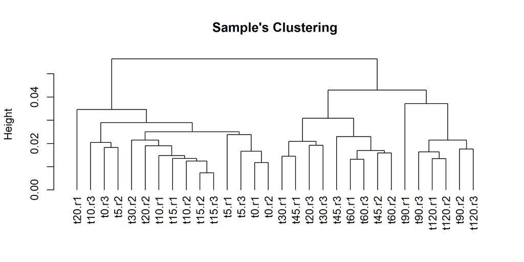

```r
TreeC = as.dendrogram(hc, method="average")
plot(TreeC,
     main = "Sample's Clustering",
     ylab = "Height")
```

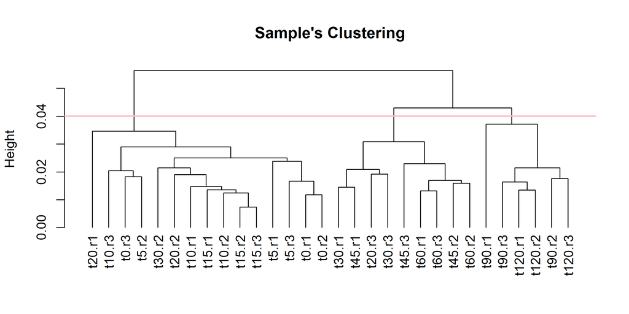

```r
TreeC = as.dendrogram(hc, method="average")
plot(TreeC,
     main = "Sample's Clustering",
     ylab = "Height")
abline(h=0.04, lwd=2, col="pink") # 0.05=2groups, 0.04=3groups, 0.03=4groups
```

This is the commmand to cut the tree and save clusters

```r
group <- as.factor(cutree(hc, h=0.04)) # 0.05=2groups, 0.04=3groups, 0.03=4groups
```

Number of clusters

```r
levels(group)
```

```
## [1] "1" "2" "3"
```

And this clustering information could be used to enrich PCA plots (next Sesion)

We have clusters, but without statistical confidence we can’t do a credible observation.

#### 6.2.2. Clustering with pvclust() function

This method calculates p-values for hierarchical clustering via multiscale bootstrap resampling. Hierarchical clustering is done for given data and p-values are computed for each of the clusters.

More info about pvclust:

```r
?pvclust
```

On this variable we will set the bootstrap value. You can set it to 10 for a quick result, but change it to 100 or even 1000 for the final figure (and meanwhile go for a coffee cup).

```r
bootstrap <- 99
pv <- pvclust(cpm(dgList3, log=TRUE, prior.count=1), method.dist="cor", method.hclust="average", nboot=bootstrap)
```

```
## Bootstrap (r = 0.5)... Done.
## Bootstrap (r = 0.6)... Done.
## Bootstrap (r = 0.7)... Done.
## Bootstrap (r = 0.8)... Done.
## Bootstrap (r = 0.9)... Done.
## Bootstrap (r = 1.0)... Done.
## Bootstrap (r = 1.1)... Done.
## Bootstrap (r = 1.2)... Done.
## Bootstrap (r = 1.3)... Done.
## Bootstrap (r = 1.4)... Done.
```

This variable is to set the number’s colors of the plot

```r
pvcolors <- c(si=4,au=2,bp=4,edge=8)
```

The cluster plot:

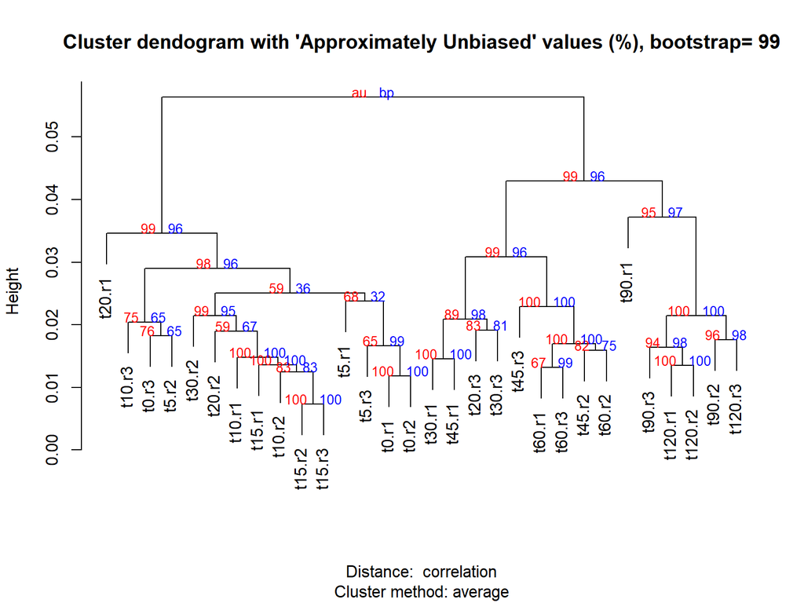

```r
plot(pv,print.num=FALSE, col.pv=pvcolors, cex.pv=0.8, main=paste("Cluster dendogram with 'Approximately Unbiased' values (%), bootstrap=", bootstrap))
```

The cluster plot selecting groups according to a specific alpha value

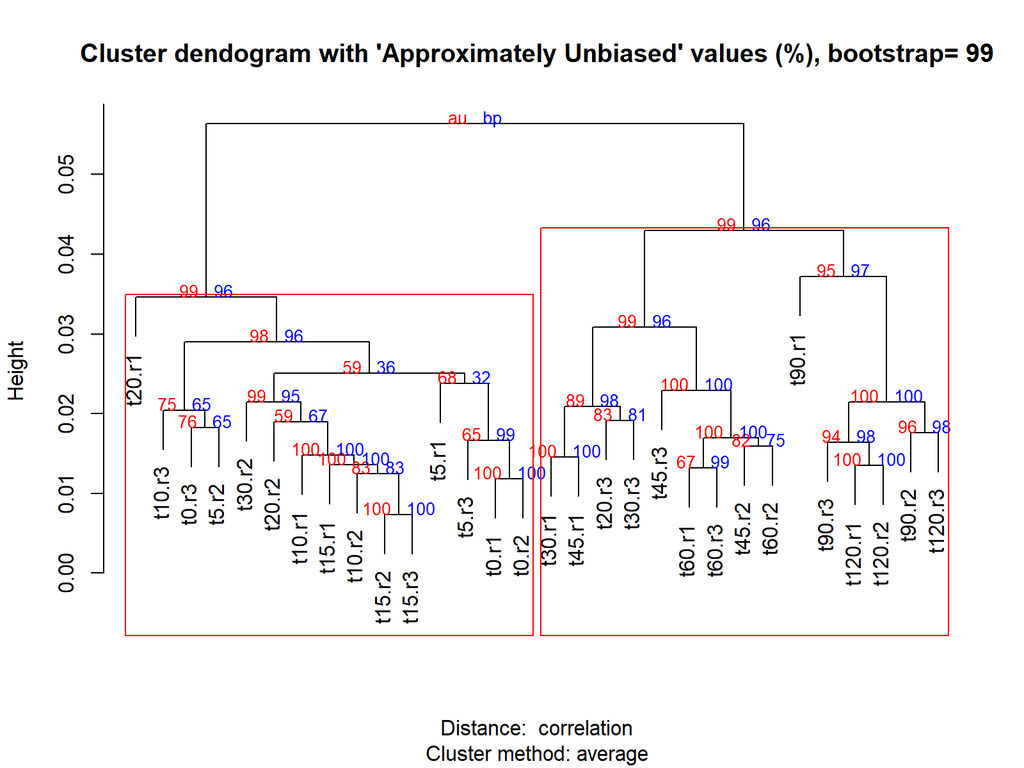

```r
plot(pv,print.num=FALSE, col.pv=pvcolors, cex.pv=0.8, main=paste("Cluster dendogram with 'Approximately Unbiased' values (%), bootstrap=", bootstrap))
pvrect(pv, alpha=0.90, pv="au", type="geq", max.only=TRUE)
```

Graph explanation: Two types of values are provided for the confidence of the nodes: AU (Approximately Unbiased) values and BP (Bootstrap Probability) values. In both cases, higher is more confident so not to be confused with conventional p-values. The AU value is computed by multiscale bootstrap resampling and is a better approximation to unbiased p-value than BP value computed by normal bootstrap resampling. Red values are AU p-values, and blue values are BP values. Clusters with AU larger than 90% are highlighted by rectangles, which are strongly supported by data.

With the following command we can select the “significant” clusters and use them in further analysis.

```r
group <- pvpick(pv, alpha=0.90, pv="au", type="geq", max.only=TRUE)
group$clusters
```

```
## [[1]]
##  [1] "t0.r1"  "t0.r2"  "t0.r3"  "t5.r1"  "t5.r2"  "t5.r3"  "t10.r1" "t10.r2"
##  [9] "t10.r3" "t15.r1" "t15.r2" "t15.r3" "t20.r1" "t20.r2" "t30.r2"
##
## [[2]]
##  [1] "t20.r3"  "t30.r1"  "t30.r3"  "t45.r1"  "t45.r2"  "t45.r3"  "t60.r1"
##  [8] "t60.r2"  "t60.r3"  "t90.r1"  "t90.r2"  "t90.r3"  "t120.r1" "t120.r2"
## [15] "t120.r3"
```

#### 6.2.3. Model based clustering

The traditional clustering methods, such as hierarchical clustering and k-means clustering, are heuristic and are not based on formal models. Furthermore, k-means algorithm is commonly randomnly initialized, so different runs of k-means will often yield different results. Additionally, k-means requires the user to specify the the optimal number of clusters.

Clustering algorithms can also be developed based on probability models, such as the finite mixture model for probability densities. The word model is usually used to represent the type of constraints and geometric properties of the covariance matrices (Martinez and Martinez, 2005). In the family of model-based clustering algorithms, one uses certain models for clusters and tries to optimize the fit between the data and the models. In the model-based clustering approach, the data are viewed as coming from a mixture of probability distributions, each of which represents a different cluster. In other words, in model-based clustering, it is assumed that the data are generated by a mixture of probability distributions in which each component represents a different cluster. Thus a particular clustering method can be expected to work well when the data conform to the model. Read More: https://epubs.siam.org/doi/abs/10.1137/1.9780898718348.ch14?mobileUi=0& https://www.datanovia.com/en/lessons/model-based-clustering-essentials/

Here we choose a model-based clustering with Mclust of the package mclust.

```r
?mclust
```

This method needs a lot of resources so, the recommendation is to use a subset of the data. For instance, we could choose a random subset or choose genes withthe highest expression variability over samples.

Use this variable to set the subset length

```r
numberRows <- 1000
```

Option1: Random selection of “numberRows” genes

```r
cpmCounts_subset.random <- cpmCounts[sample(nrow(cpmCounts), numberRows), ]
```

Option2: Selection of genes with the highest expression variation. We will use the function rowSds to select the top “numberRows” genes.

```r
orderPositions <- order(rowSds(cpmCounts), decreasing=T)
cpmCounts_subset.Sds <- cpmCounts[orderPositions,][1:numberRows,]
```

> Try both options and compare results)

Now, let’s fit the data to a model using Mclust function

```r
fit <- Mclust(t(cpmCounts_subset.random), scale.=FALSE)
```

view solution summary… what’s the used model? what it means?

```r
fit
```

```
## 'Mclust' model object: (VEI,3)
##
## Available components:
##  [1] "call"           "data"           "modelName"      "n"
##  [5] "d"              "G"              "BIC"            "loglik"
##  [9] "df"             "bic"            "icl"            "hypvol"
## [13] "parameters"     "z"              "classification" "uncertainty"
```

Information about models:

```r
?mclustModelNames
```

Lookup all the attempted options

```r
summary(fit$BIC)
```

```
## Best BIC values:
##              VEI,3        EEI,3       VEI,4
## BIC      -12764.53 -12779.11137 -12943.2717
## BIC diff      0.00    -14.58347   -178.7438
```

Models and their score by component

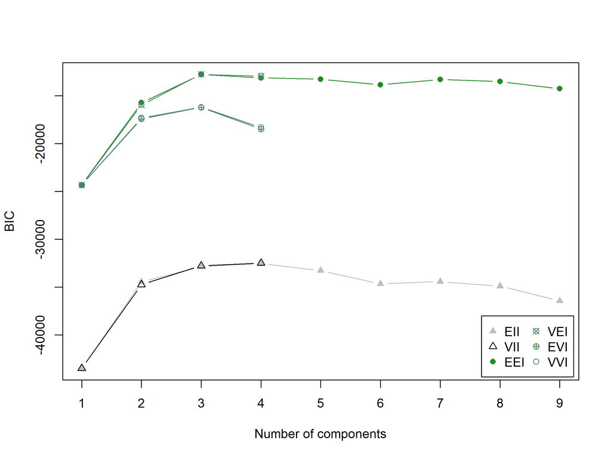

```r
plot(fit$BIC)
```

Classification vector that we could use on other plots, like PCA (next Sesion)

```r
group = as.factor(fit$classification) # classification vector
```

Number of clusters

```r
levels(group)
```

```
## [1] "1" "2" "3"
```

### 6.3. Heatmap of samples distance using mixOmics package

We can examine inter-sample relationships by producing heatmap of samples distance.

There are several functions to do a Heatmaps in R. Here we will use cim function that comes with the package mixOmics.

```r
Log2_pseudoCounts <- log2(dgList3$counts+1)
sampleDists <- as.matrix(dist(t(Log2_pseudoCounts)), method = "cor")
```

Setting a color pallete over red color:

```r
cimColor <- colorRampPalette(rev(brewer.pal(9, "Reds")))(20)
```

Before to plot the next figure, expand the RStudio plot panel.

> In general, if you receive a “margins too large” message, try to expand the RStudio plot panel and try again.

> Another solution for large figures is to execute a **x11()** command before each plot. This will activate a new window where the next plot will be diplayed.

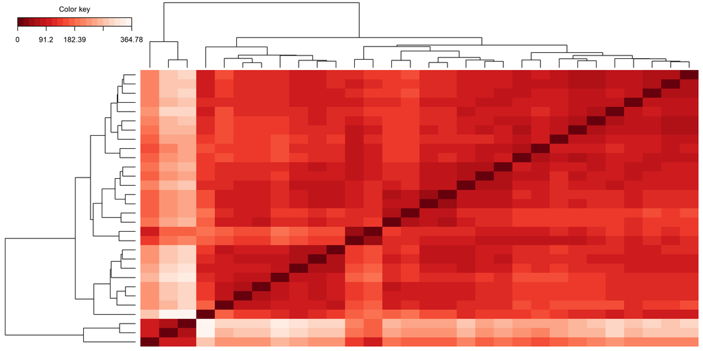

```r
cim(sampleDists, color = cimColor, symkey = FALSE, row.cex = 1.3, col.cex = 1.3, margins = c(0.5, 0.5))
```

What if we use cpm instead of pseudocount?

```r
cpmCounts <- cpm(dgList3, log=TRUE, prior.count = 1)
sampleDists <- as.matrix(dist(t(cpmCounts)), method = "cor")
```

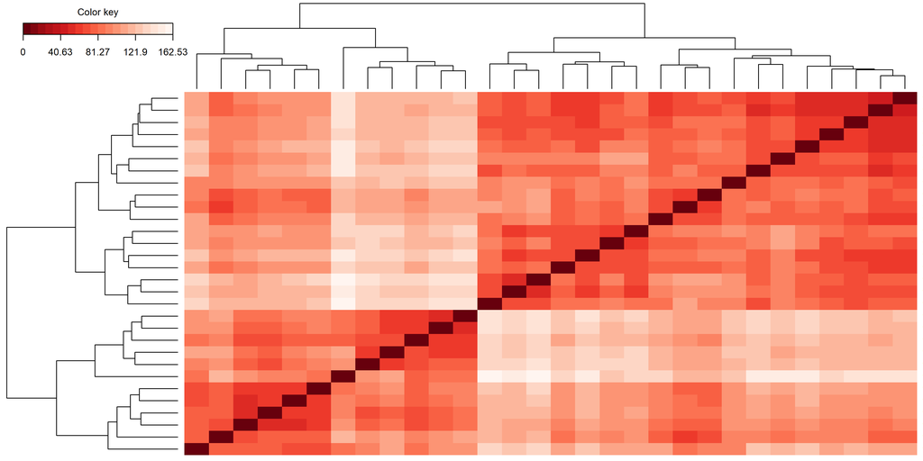

```r
cim(sampleDists, color = cimColor, symkey = FALSE, row.cex = 1.3, col.cex = 1.3, margins = c(0.5, 0.5))
```

Note that sample clustering is different when using pseudocounts or cpm. The distance between samples is sensible to the kind of data that you use and pseudocounts are different than cpm, as you see on the panel C and D of the first graph of data transformation section. Some people do prefer to use pseudocounts but the correct way is to use cpm (https://www.biostars.org/p/165619/).

## 7. Lineal model

Linear modelling in edgeR is carried out using the glmFit (GLM) and contrasts.fit functions originally written for application to microarrays. The functions can be used for both microarray and RNA-seq data and fit a separate model to the expression values for each gene. Next, empirical Bayes moderation is carried out by borrowing information across all the genes to obtain more precise estimates of gene-wise variability (Smyth 2004).

Here, we fit a GLM to account for the time effect.

### 7.1. Creating the model

In our analysis, linear models are fitted to the data with the assumption that the underlying data is normally distributed. To get started, a design matrix is set up with both time series information. This matrix describes the setup of the experiment.

Our dataset have have 30 samples that belongs to 10 “times” with triplicates, we will use “Time” as the comparison factor.

```r
design.matrix <- model.matrix(~ dgList3$samples$group)
length(design.matrix[1,]) #10 factors
```

```
## [1] 10
```

Number of factors

```r
length(design.matrix[1,]) #10 factors
```

```
## [1] 10
```

Detail of factors and assigned samples: 30 rows for 30 samples. You can see a number “1” on the corresponding replicates of each sample. Note that **dgList3$samples$group0** is not present. As a time series, all factors will be compared against time0.

```r
design.matrix # factors
```

```
##    (Intercept) dgList3$samples$group5 dgList3$samples$group10
## 1            1                      0                       0
## 2            1                      0                       0
## 3            1                      0                       0
## 4            1                      1                       0
## 5            1                      1                       0
## 6            1                      1                       0
## 7            1                      0                       1
## 8            1                      0                       1
## 9            1                      0                       1
## 10           1                      0                       0
## 11           1                      0                       0
## 12           1                      0                       0
## 13           1                      0                       0
## 14           1                      0                       0
```

[output cut: 114 more lines]

Another model option is to use **model.matrix(0~ + dgList3$samples$group)**, but that’s not a time series analysis. That’s a matrix for paired comparisons (ie, control vs treatment) like will be used on next Session.

A key strength of limma’s linear modelling approach, is the ability accommodate arbitrary experimental complexity. Simple designs, such cell type and batch, through to more complicated factorial designs and models with interaction terms can be handled relatively easily. Where experimental or technical effects can be modelled using a random effect, another possibility in limma is to estimate correlations using duplicateCorrelation by specifying a block argument for both this function and in the lmFit linear modelling step.

### 7.2. Estimating dispersions

We need to estimate the dispersion parameter for our negative binomial model. If there are only a few samples, it is difficult to estimate the dispersion accurately for each gene, and so we need a way of’sharing’ information between genes. Possible solutions include: - Using a common estimate across all genes. - Fitting an estimate based on the mean-variance trend across the dataset, such that genes with similar abundances have similar variance estimates (trended dispersion). - Computing a genewise dispersion (tagwise dispersion)

In edgeR, we use an empirical Bayes method to ‘shrink’ the genewise dispersion estimates towards the common dispersion (tagwise dispersion). Note that either the common or trended dispersion needs to be estimated before we can estimate the tagwise dispersion.

```r
dgList3a <- estimateGLMCommonDisp(dgList3, design=design.matrix)
dgList3a <- estimateGLMTrendedDisp(dgList3a, design=design.matrix)
dgList3a <- estimateGLMTagwiseDisp(dgList3a, design=design.matrix)
```

We can plot the estimates and see how they differ. The biological coefficient of variation (BCV) is the square root of the dispersion parameter in the negative binomial model.

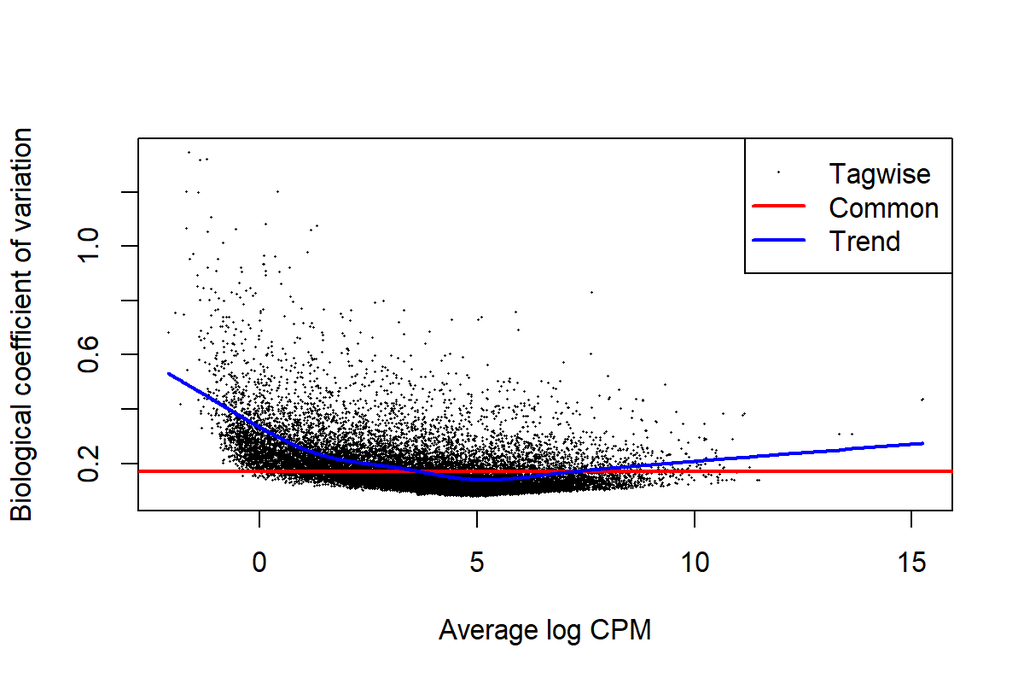

```r
plotBCV(dgList3a)
```

There is a function in EdgeR that merges the three previous commands but, the result is not the same therefore, we prefer the three step method. “The estimateDisp function doesn’t give exactly the same estimates as the traditional calling sequences”.

```r
dgList3b <- estimateDisp(dgList3, design.matrix,trend.method="locfit")
```

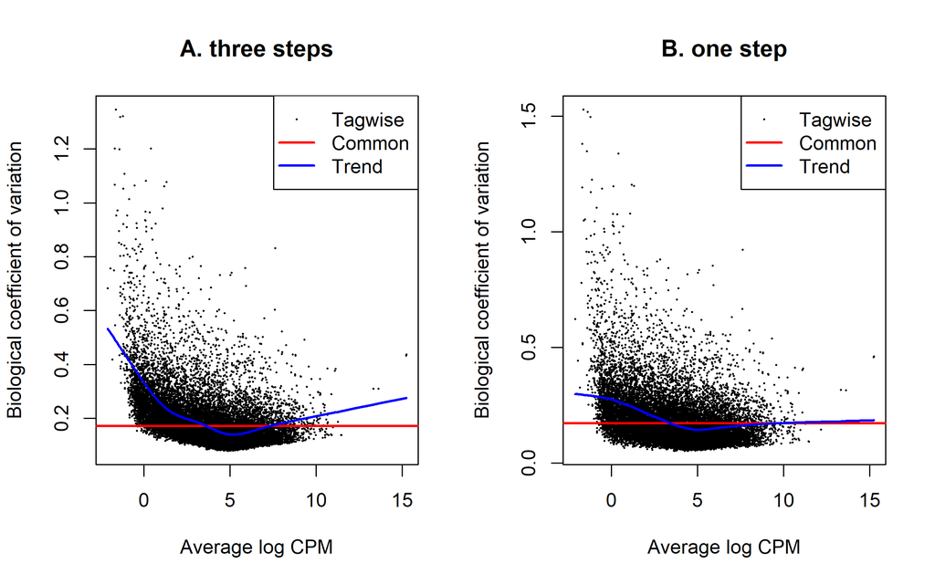

```r
par(mfrow=c(1,2))
plotBCV(dgList3a)
title(main="A. three steps")
plotBCV(dgList3b)
title(main="B. one step")
```

The trend is more realistic using “three steps” method. Finally, we choose to follow using that result

```r
dgList3 <- dgList3a
```

### 7.3. Fitting and making comparisons

Now, we can use edgeR as a GLM. First fit the data to the count model before making contrasts of interest.

```r
fit <- glmFit(dgList3, design.matrix)
fit$method
```

```
## [1] "oneway"
```

Let’s see the coefficients of this model as derived from the design matrix (colnames of table):

```r
colnames(fit) # factors
```

```
##  [1] "(Intercept)"              "dgList3$samples$group5"
##  [3] "dgList3$samples$group10"  "dgList3$samples$group15"
##  [5] "dgList3$samples$group20"  "dgList3$samples$group30"
##  [7] "dgList3$samples$group45"  "dgList3$samples$group60"
##  [9] "dgList3$samples$group90"  "dgList3$samples$group120"
```

```r
lrt <- glmLRT(fit,coef=6)
#kable(head(lrt$table))
head(lrt$table)
```

```
##                logFC    logCPM         LR      PValue
## AT1G01010 -0.2026954 4.3646484 1.19714677 0.273892693
## AT1G01020  0.0339595 3.7150330 0.04185692 0.837892753
## AT1G01030 -0.2237841 1.6000858 0.87071276 0.350758061
## AT1G01040 -0.1780170 6.4567675 2.10480894 0.146836683
## AT1G03993 -0.8292579 2.6110069 7.45770623 0.006316544
## AT1G01046 -0.1014080 0.4601438 0.13504169 0.713260865
```

This result does not have FDR correction The following lines will add this correction using the function topTags

```r
lrtFDR <- topTags(lrt, n = nrow(dgList3$counts))
#kable(head(lrtFDR$table))
head(lrtFDR$table)
```

```
##               genes    logFC   logCPM       LR        PValue           FDR
## AT3G49940 AT3G49940 7.728044 6.307248 647.1966 9.094910e-143 2.004791e-138
## AT5G40850 AT5G40850 5.227322 9.356019 463.4374 8.587392e-103  9.464594e-99
## AT4G37540 AT4G37540 8.859143 3.832665 425.8077  1.328463e-94  9.761103e-91
## AT5G63160 AT5G63160 4.450219 4.399648 424.1120  3.107669e-94  1.712559e-90
## AT5G67420 AT5G67420 6.640411 7.654433 395.7192  4.707948e-88  2.075546e-84
## AT1G68670 AT1G68670 5.142652 4.610942 390.7073  5.806269e-87  2.133126e-83
```

Now we included FDR correction :)

We want to keep only gene with significant expression difference across time so, we could filter our data with a 2X fold of change cutoff and a FDR < 0.05 or less. Some people only use the FDR cutoff but, that’s only a numerical significance… a confidence that two numbers are sufficiently different considering a distribution model. However, an important concept to keep in mind is the biological significance: having twice the concentration of transcripts (2X) is a starting point to filter out genes without a real impact on the phenotype. Of course, there are some genes that with low increments will produce big changes. My advice is to fisrt evaluate final numbers of selected genes with the standard cutoff. This because downstream analysis don’t work well with big numbers. You would like to work with a subset of the data (hundreds to several thousands), not all the genes.

```r
selectedLRT.list <- lrtFDR$table$FDR < 0.05 & abs(lrtFDR$table$logFC) > 1
selectedLRT <- lrtFDR$table[selectedLRT.list, ]
nrow(selectedLRT)
```

```
## [1] 1056
```

“selectedLRT” is the list of genes with a expression pattern on “time 30” that differ from the linear model.

The following are the number of genes calculated for each coeficient of the design matrix and what they represent.

```r
lrt210 <- glmLRT(fit,2:10)
```

```r
lrt210FDR <- topTags(lrt210, n = nrow(dgList3$counts)) # adds FDR correction
```

```r
selectedLRT210 <- lrt210FDR$table$FDR < 0.05
selectedLRT210 <- lrt210FDR$table[selectedLRT210, ]
nrow(selectedLRT210)
```

```
## [1] 12185
```

Now, we can explore expression of selected DE genes of factor 6 using different plots.

#### 7.3.1. MA plot of selected genes

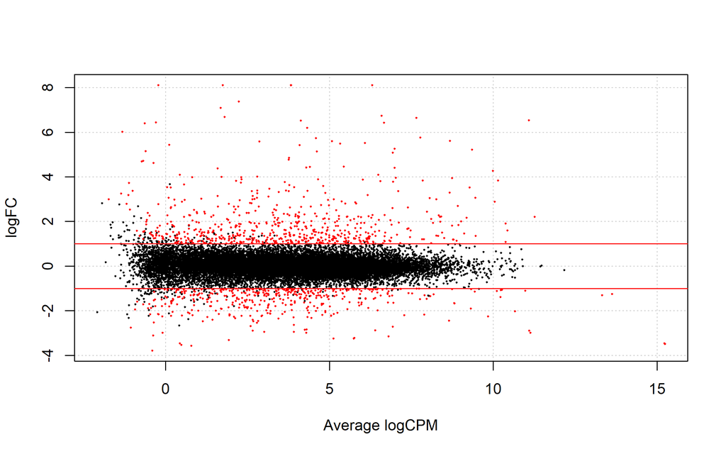

```r
plotSmear(lrt, de.tags = rownames(selectedLRT))
abline(h=c(-1, 1), col=2)
```

#### 7.3.2. Volcano plot of selected genes

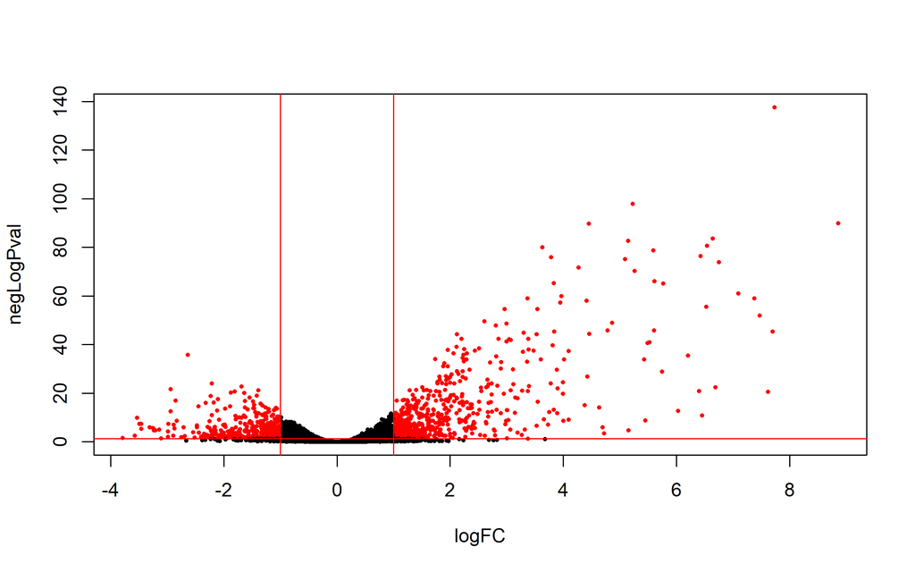

```r
volcanoData <- cbind(lrtFDR$table$logFC, -log10(lrtFDR$table$FDR))
colnames(volcanoData) <- c("logFC", "negLogPval")
point.col <- ifelse(selectedLRT.list, "red", "black")
plot(volcanoData, pch = 16, col = point.col, cex = 0.5)
abline(v=c(-1, 1), col=2)
abline(h=-log10(0.05), col=2)
```

#### 7.3.3. Heatmap of selected genes using cpm

Selecting the subset

```r
cpmCounts.select <- cpmCounts[match(rownames(selectedLRT), rownames(dgList3$counts)), ]
```

Ploting a heatmap of selected genes with “Samples as rows”

```r
finalHMr <- cim(t(cpmCounts.select), color = cimColor, symkey = FALSE, row.cex = 1,
               col.cex = 0.7)
```

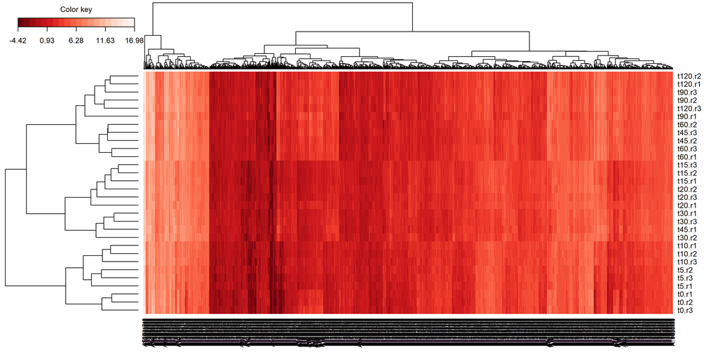

Ploting a heatmap with “Samples as columns”

```r
finalHMc <- cim(cpmCounts.select, color = cimColor, symkey = FALSE, row.cex = 0.7,
               col.cex = 1.5)
```

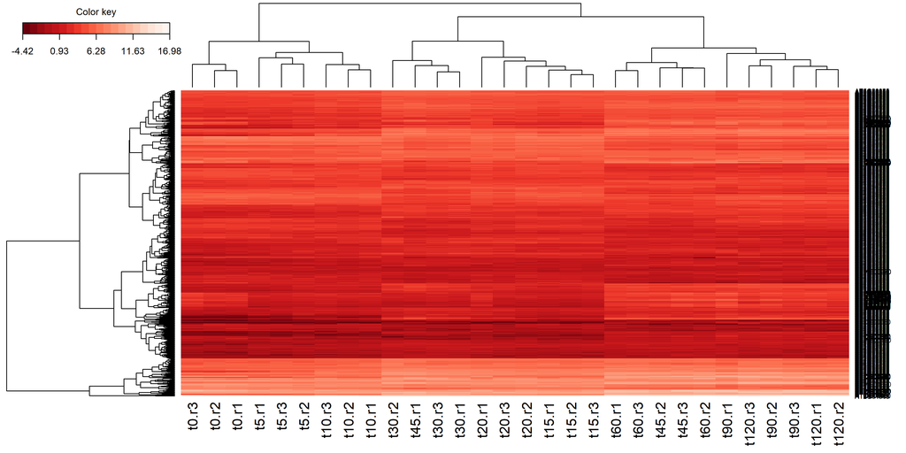

#### 7.3.4. Some other heatmaps schemes

Default heatmap.2 output

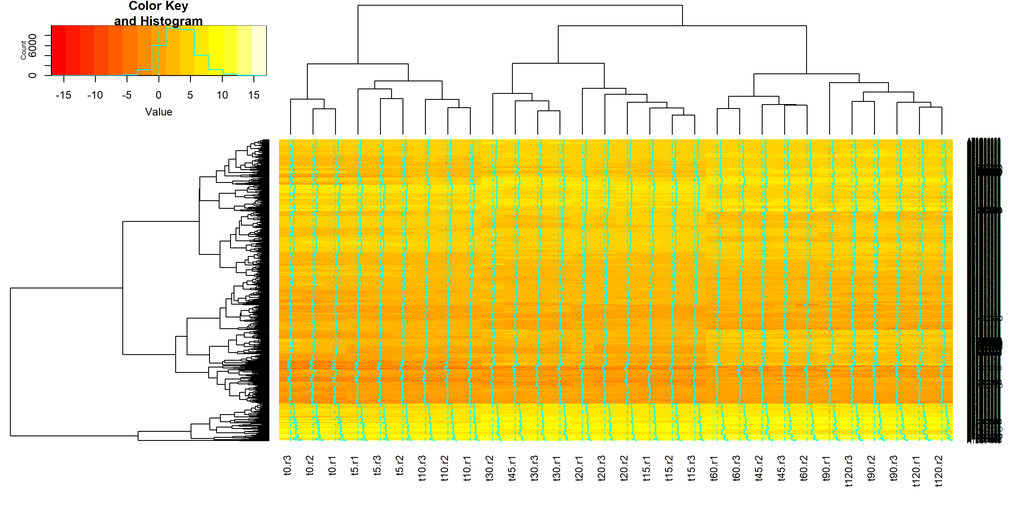

```r
heatmap.2(cpmCounts.select)
```

Scaling by genes (rows)… also known as z-score

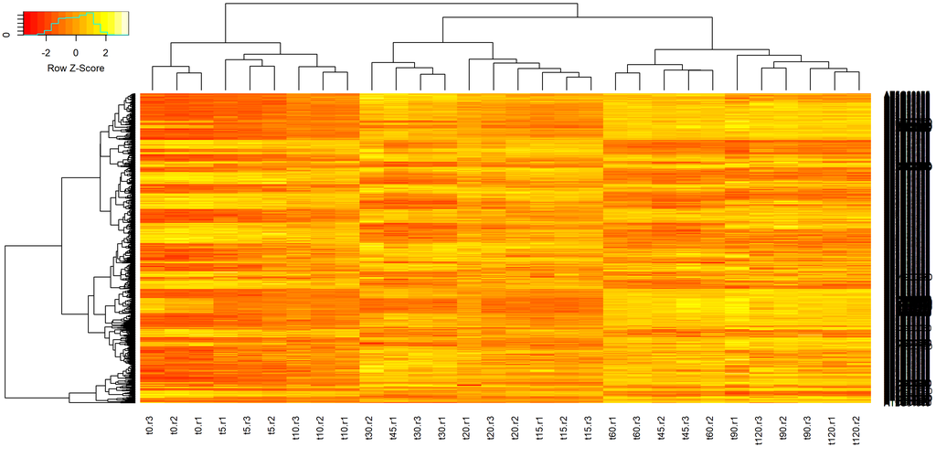

```r
heatmap.2(cpmCounts.select,scale="row", trace="none", cexRow = 0.8,
          keysize = 1, key.title = NA, key.ylab = NA,
          lmat = matrix(c(4,2,3,1),
            nrow=2,
            ncol=2),
          lhei = c(0.2,0.8),
          lwid = c(0.15,0.85)
)
```

Grouping samples by time with a distintive color

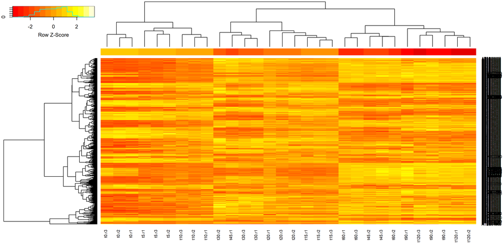

```r
heatmap.2(cpmCounts.select,scale="row", trace="none", cexRow = 0.8,
          ColSideColors=Color,
          keysize = 1, key.title = NA, key.ylab = NA,
)
```

More options:

```r
?heatmap.2
```

### 7.4. Gene clustering of selected genes

In clustering we are interested in whether there are groups of genes or groups of samples that have similar gene expression patterns. The first thing that we have to do is to articulate what we mean by similarity or dissimilarity as expressed by a measure of distance. We can then use this measure to cluster genes or samples that are similar. Here, we will use DE genes to generate a set of clusters with similar expression.

#### 7.4.1. Dendogram of genes

You could use any of the methods described in “Clustering analysis” (Section 6.2)

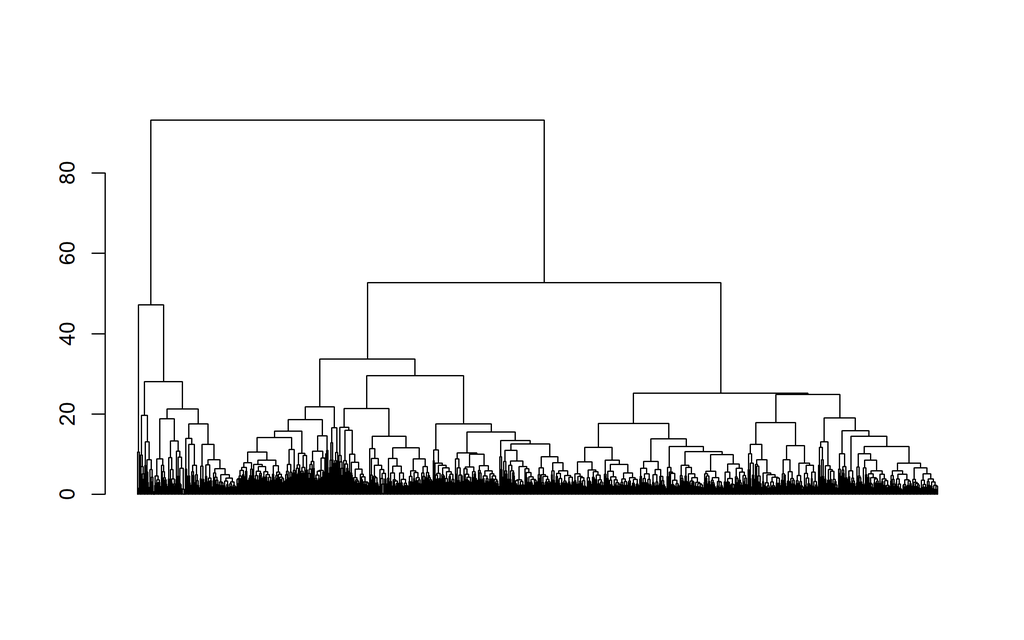

```r
plot(finalHMc$ddr, leaflab="none")
```

The tree could be “cutted” at a desired level to obtain clusters. If we cut at 40%, we will produce 4 clusters

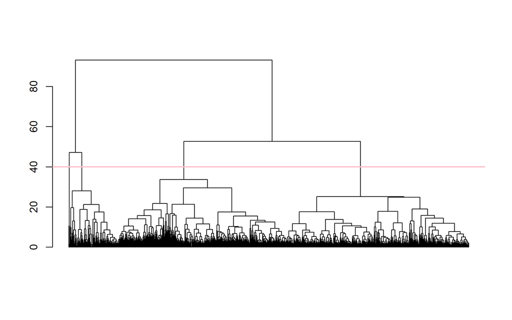

```r
plot(finalHMc$ddr, leaflab="none")
abline(h=40, lwd=2, col="pink")
```

This is the commmand to cut the tree at the desired level and save clusters:

```r
geneClust <- cutree(as.hclust(finalHMc$ddr), h=40) # 50x3 40x4 30x5
```

Number of clusters

```r
length(unique(geneClust))
```

```
## [1] 4
```

Listing gene names of cluster 2:

```r
names(which(geneClust == 2))
```

```
##   [1] "AT5G40850" "AT5G67420" "AT2G15620" "AT1G35560" "AT5G41670" "AT5G09800"
##   [7] "AT1G24280" "AT2G22500" "AT4G38340" "AT3G57450" "AT1G30510" "AT1G08657"
##  [13] "AT1G77760" "AT5G50200" "AT4G05390" "AT5G13110" "AT2G27510" "AT1G63940"
##  [19] "AT1G64190" "AT1G13000" "AT3G28690" "AT1G32920" "AT5G03380" "AT1G71980"
##  [25] "AT5G53460" "AT1G70780" "AT3G47520" "AT2G36580" "AT2G40140" "AT4G36020"
##  [31] "AT5G54170" "AT1G68550" "AT4G24020" "AT5G12860" "AT5G65010" "AT2G30590"
##  [37] "AT2G38170" "AT1G37130" "AT1G70410" "AT1G64140" "AT3G55980" "AT1G63860"
##  [43] "AT4G04125" "AT4G02380" "AT1G68840" "AT5G25350" "AT1G29400" "AT1G80325"
##  [49] "AT2G29670" "AT1G80310" "AT5G53420" "AT1G43710" "AT5G65310" "AT3G24190"
##  [55] "AT5G57660" "AT2G17820" "AT2G24600" "AT3G60750" "AT4G17090" "AT4G18700"
##  [61] "AT5G14760" "AT1G25560" "AT2G32680" "AT2G31955" "AT4G05685" "AT1G08477"
##  [67] "AT1G21110" "AT2G28890" "AT5G51830" "AT4G17550" "ATMG01390" "AT4G32020"
##  [73] "AT1G51805" "AT4G34135" "AT3G17609" "AT2G38470" "AT1G12110" "AT1G62180"
##  [79] "ATCG01210" "AT4G30350" "ATCG00920" "AT3G23030" "AT1G54130" "AT1G21120"
##  [85] "AT2G36530" "AT4G05320" "AT4G15550" "AT4G24400" "AT4G17770" "AT1G66390"
##  [91] "AT3G10420" "AT5G19240" "AT2G37040" "AT3G23920" "AT5G40450" "AT3G16150"
##  [97] "AT3G25610" "AT4G11890" "AT4G12290" "ATCG00280" "AT2G01021" "AT4G27260"
## [103] "AT1G12940" "AT1G61800" "AT1G74810" "AT4G32940" "AT1G74360" "AT5G57220"
## [109] "AT3G28510" "ATMG00020" "ATCG00900" "ATCG00270" "ATCG01240" "AT2G01020"
## [115] "AT3G41979" "AT3G06355" "AT1G28290" "AT2G16060" "AT5G42830" "AT4G22495"
## [121] "AT4G22505" "AT5G03350" "AT4G22475" "AT4G22467" "AT5G20230" "AT4G22485"
## [127] "AT4G22470"
```

To know the number of genes on each cluster:

```r
length(names(which(geneClust == 1)))
```

```
## [1] 480
```

```r
length(names(which(geneClust == 2)))
```

```
## [1] 127
```

```r
length(names(which(geneClust == 3)))
```

```
## [1] 445
```

```r
length(names(which(geneClust == 4)))
```

```
## [1] 4
```

#### 7.4.2. Expression patterns of group of genes

Now, we would like to see the expression pattern of each cluster. We will use cpm data.

```r
scaledata <- cpmCounts.select
```

We need a function to obtain the mean expression on each sample of a desired cluster:

```r
clust.core = function(i, dat, clusters) {
  ind = (clusters == i)
  colMeans(dat[ind,])
}
```

When we apply the function, there will be obtained core expression of each cluster

```r
cores <- sapply(unique(geneClust), clust.core, scaledata, geneClust)
head(cores)
```

```
##           [,1]     [,2]      [,3]     [,4]
## t0.r1 3.836735 6.837619 0.4369388 14.38216
## t0.r2 3.794091 6.823880 0.3822376 14.53585
## t0.r3 3.762711 6.812320 0.4549936 15.22181
## t5.r1 3.811902 6.764831 0.3792206 13.26071
## t5.r2 3.892364 6.808391 0.5684919 12.94931
## t5.r3 3.853511 6.838176 0.3392000 13.07987
```

Now, we prepare the data frame

```r
d <- data.frame(cbind(dgList$metadata$Time,cores))
#names <- rownames(d)
#rownames(d) <- NULL
#d <- cbind(names,d)
colnames(d) <-c("time", paste0("clust_",1:ncol(cores)))

#get the data frame into long format for plotting
dmolten <- melt(d, id.vars = "time")
#order by time
dmolten <- dmolten[order(dmolten$time),]
breaks=c(as.numeric(levels(factor(dgList$metadata$Time))))
```

Make the plot:

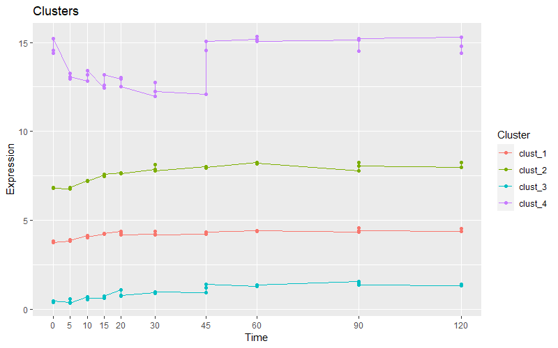

```r
p0 <- ggplot(dmolten, aes(time, value, col=variable)) +
  geom_point() +
  geom_line() +
  scale_x_continuous(minor_breaks = NULL, breaks=breaks) +
  xlab("Time") +
  ylab("Expression") +
  labs(title= "Clusters",color = "Cluster")
p0
```

We can select a specific cluster to draw the expression of their genes. I will select cluster1

**Cluster 1**

Subset the complete data by cluster =1:

```r
dClust1 <- t(scaledata[geneClust==1,])
# add the time
dClust1 <- data.frame(cbind(data.frame(dgList$metadata$Time),dClust1))
colnames(dClust1)[1] <- "time"
# get the data frame into long format for plotting
dClust1molten <- melt(dClust1, id.vars = "time")
# order by time
dClust1molten <- dClust1molten[order(dClust1molten$time),]
# Subset the cores molten dataframe so we can plot core1
core1 <- dmolten[dmolten$variable=="clust_1",]
```

Now, to plot this gene expression we use the group=variable and change the geom_line to grey. Then we add on top of expression the mean expression of the core in blue passing the the core data to geom_line.

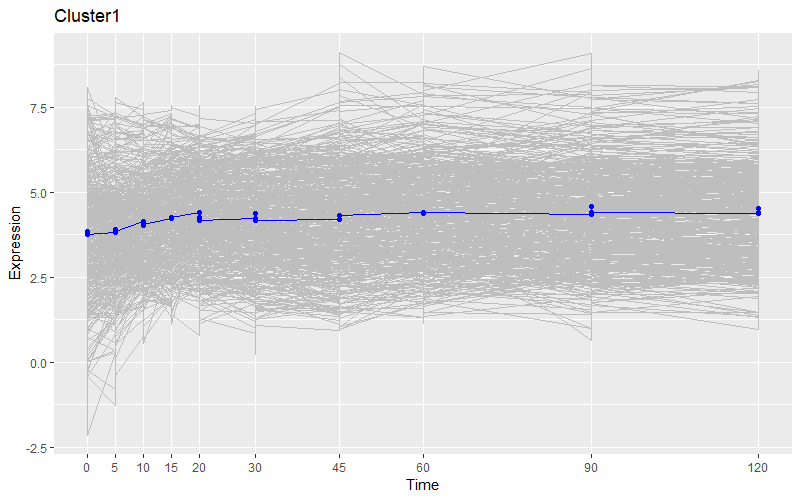

```r
p1 <- ggplot(dClust1molten, aes(time, value, group=variable)) +
  geom_line(color="grey") +
  geom_point(data=core1, aes(time,value), color="blue") +
  geom_line(data=core1, aes(time,value), color="blue") +
  scale_x_continuous(minor_breaks = NULL, breaks=breaks) +
  xlab("Time") +
  ylab("Expression") +
  labs(title= "Cluster1", color = "Cluster")
p1
```

**All clusters**

```r
#Function to create plots
cluster_plot<- function(scaledata, clust){
  dClust <- t(scaledata[geneClust==clust,])
  #add time
  dClust <- data.frame(cbind(data.frame(dgList$metadata$Time),dClust))
  colnames(dClust)[1] <- "time"
  #get the data frame into long format for plotting
  dClustmolten <- melt(dClust, id.vars = "time")
  #order by time
  dClustmolten <- dClustmolten[order(dClustmolten$time),]
  #Subset the cores molten dataframe so we can plot core1
  core <- dmolten[dmolten$variable==paste0("clust_",clust),]

  p <- ggplot(dClustmolten, aes(time,value, group=variable)) +
  geom_line(color="grey") +
  geom_point(data=core, aes(time,value), color="blue") +
  geom_line(data=core, aes(time,value), color="blue") +
  scale_x_continuous(minor_breaks = NULL, breaks=c(as.numeric(levels(factor(dmolten$time))))) +
  xlab("Time") +
  ylab("Expression") +
  labs(title= paste0("Cluster",clust),color = paste0("Cluster",clust))
return(p)
}
```

```r
p2 <- cluster_plot(scaledata, 2)
p3 <- cluster_plot(scaledata, 3)
p4 <- cluster_plot(scaledata, 4)
```

Now, we are ready to plot all clusters:

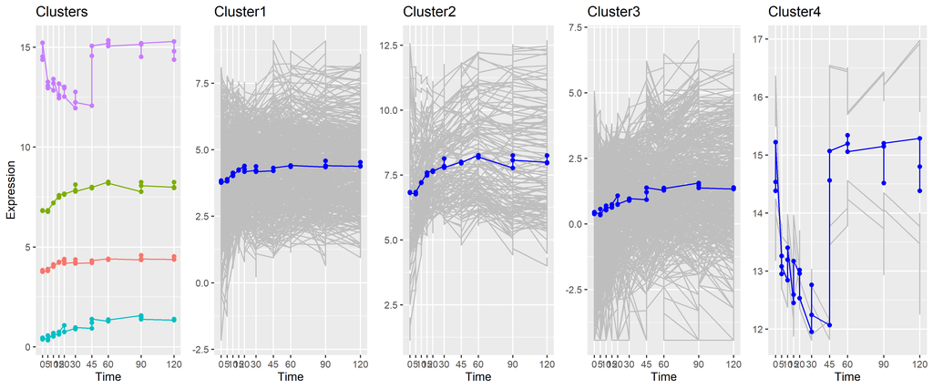

```r
# Expand the RStudio plot panel before the plot
grid.arrange(p0 + theme(legend.position = "none"),
             p1+ ylab(NULL),
             p2+ ylab(NULL),
             p3+ ylab(NULL),
             p4+ ylab(NULL),
             ncol=5)
```

Cool, but each graph have their own scale and they are not sorted. Look for the max and min axes value through the graphs to set global values.

```r
# Setting min a max limits of y axes based on all five plots
ylim1=-5; ylim2=17
```

Finally, sort the command lines of expression plots according to p0 order and plot!

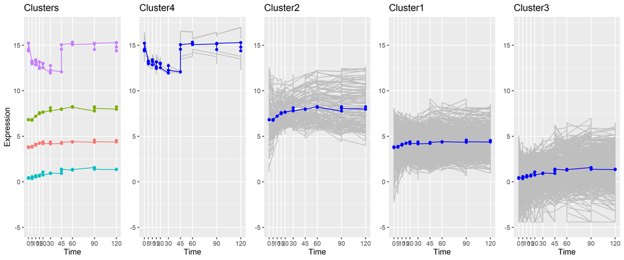

```r
# Expand the RStudio plot panel before the plot
grid.arrange(p0 + ylim(ylim1, ylim2) + theme(legend.position = "none"),
             p4 + ylim(ylim1, ylim2) + ylab(NULL),
             p2 + ylim(ylim1, ylim2) + ylab(NULL),
             p1 + ylim(ylim1, ylim2) + ylab(NULL),
             p3 + ylim(ylim1, ylim2) + ylab(NULL),
             ncol=5)
```

#### 7.4.3. Saving results

Now, you would want to know what functions are represented on this selected genes. This will be explained on session5.

Meanwhile you can save the gene list of each cluster nor the list of all clusters to a text file to be ready.

```r
# Cluster2 of factor6
write.table(names(which(geneClust == 2)), "factor6.clust2.txt", sep="\t", quote = FALSE, row.names = F, col.names = F)

# All genes of factor6
write.table(names(geneClust), "factor6.all.txt", sep="\t", quote = FALSE, row.names = F, col.names = F)
```